# 1) Introduction

This report is for IE360 Project, which was about forecasting the future sales of nine different products with the possible help of various variables, which were all provided by Trendyol. Apart from the date and the product content id, the variables that are provided for all the products are, namely, price, sold count, visit count, basket count, favoured count, category sold count, category visit count, category basket count, category favoured count, category brand sold count, and Trendyol visit count. The variable names are self-explanatory; however, to explain further,

- Price variable was for the prices of each product day by day, which was provided in case the sold count depends on the price of the product.
- Sold count variable was for how many of that product were sold on the given day. Sometimes setting up a model using the lagged variables of the target variable helps more than using other variables.
- Visit count variable was for how many times the page of that product is visited on the given day. If this variable has a significant effect on the quantity sold, then putting it forward in the algorithm may help the product to sell more than any other actions that can be taken.
- Basket count variable was for how many times that product was put in the basket of a user on the given day. This variable may help one to understand how many times a user changes their mind and does not decide to buy the product that they put in their basket.
- Favoured count variable was for how many times the product was favoured by a user. This variable also shows how many people liked the product but postponed buying it due to several reasons that cannot be found that easily.
- Category sold count variable was for the total amount sold belonging one category. This variable may indicate the specific times that a product type is needed because sometimes seasonality is on the table and a product may not be bought not because of its price or other characteristic, but just because it is not the time for it.
- Category visit count variable was for the times that a category page was visited. Likewise, this variable also shows when a category is in demand or not needed.
- Category basket count variable was for how many times the category that the product belongs to was put in the basket of a user. Similar to other category variables, this variable also shows how many people considers buying from that category in general, which can be related to sales of that products due to the need or want for that category.
- Category favoured count variable was for how many times a product belonging that category was favoured. Again, this variable also indicates how much a product from that category is at least considered to be bought.
- Category brand sold count variable was for how much was sold from the brand of the product on the given day. Sometimes, when brands are more seen than before due to many reasons, such as the algorithm putting forward that brand or maybe a new marketing strategy, the products of those brands find more customers than normal days. Hence, this variable may help understanding the sales of the product.
- Lastly, Trendyol visit count variable was for how many times the website Trendyol was visited on the given day. This variable may help one to distinguish some important days from others, such as a discount day. Although the discount may not affect the price of the product , when a person decides to check random products in Trendyol due to a discount, they may encounter the product of interest and decide to buy it. Hence, this variable may also be helpful in analysing the sold counts.

Although we had these variables that can be used to approximate different possible occurrences that might affect the sold counts for products, which were explained above, our regressions did not give us what we hoped for. Therefore, after running some regressions, we decided to go with standard ARIMA models because they seemed better due to the low adjusted R-squared values of the regressions that we checked. Therefore, after analysing each product, we used appropriate ARIMA models to approach the data and predict the next day, every day. After showing our analyses of each product, we will explain our models in detail, and discuss our results and approach, with their positive and negative sides.

# 2. Approach

In this section, although the process for finding a suitable model and predicting the future was much or less the same for all of them, at least the analyses will be explained separately. In essence, we searched for different possible regressors that may better the analysis and forecasts of the sold counts, but since we could not find anything that can explain the data well after removing the trend and seasonality components in order to make the data stationary, we proceeded with standard ARIMA model, as indicated above.

## i) Coat from ALTINYILDIZ CLASSICS (Product Id: 48740784)

The plot of the sold count of the coat is below.

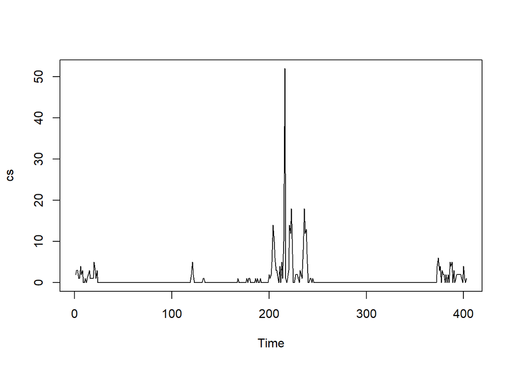

The plot of daily decomposition of the data is below. The type used is additive.

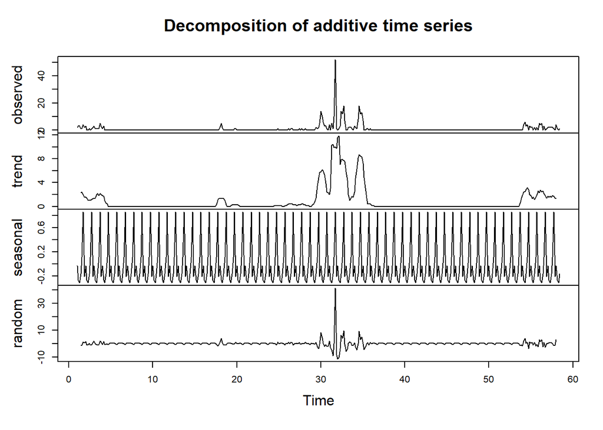

When the data is decomposed, the results are as above. Here, the increase in the middle can still be observed in the detrended and deseasonalised data (the random component). Now, in order to be able to run an ARIMA model, the stationarity of the random component must be examined. After assigning random_cs as the random component of the decomposed series, we used KPSS Test to see if the data is stationary.

```
##
##  KPSS Test for Level Stationarity
##
## data:  random_cs
## KPSS Level = 0.010121, Truncation lag parameter = 5, p-value = 0.1
```

Since the null-hypothesis of the KPSS Test is that the data is stationary, we must fail to reject it. Here, the p-value, which suggests that we fail to reject the null-hypothesis, shows that the random component is stationary. Therefore, we can run an ARIMA model, for which we checked ACF and PACF plots, before using the auto.arima function.

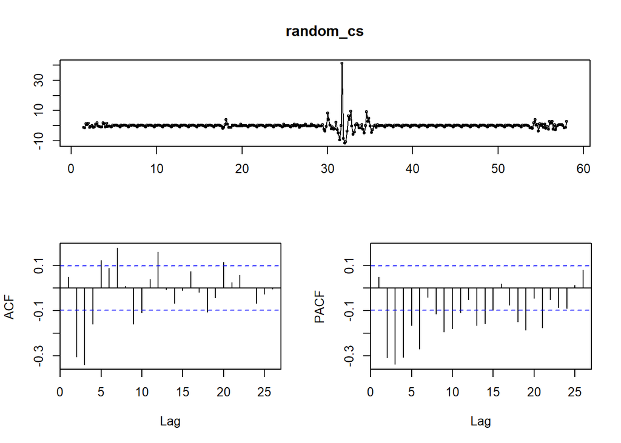

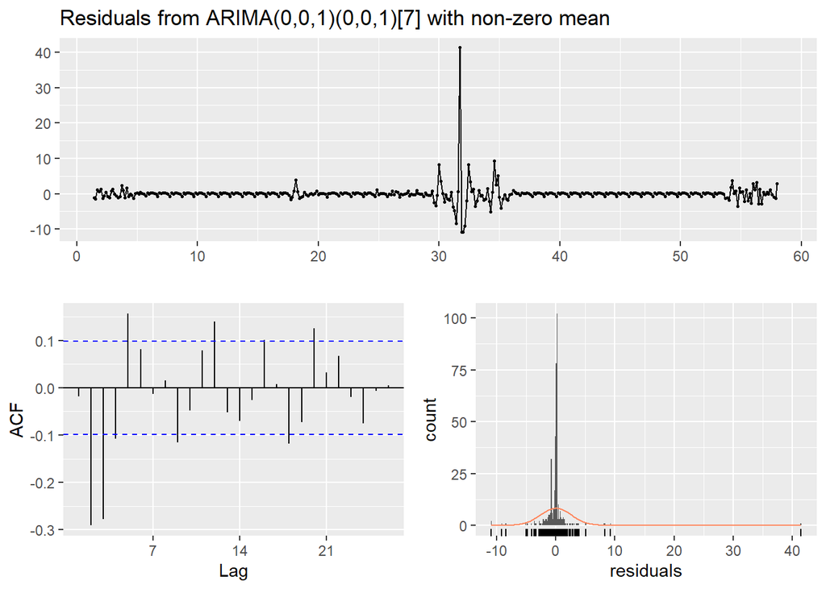

```
##
##  Ljung-Box test
##
## data:  Residuals from ARIMA(0,0,1)(0,0,1)[7] with non-zero mean
## Q* = 102.25, df = 11, p-value < 2.2e-16
##
## Model df: 3.   Total lags used: 14
```

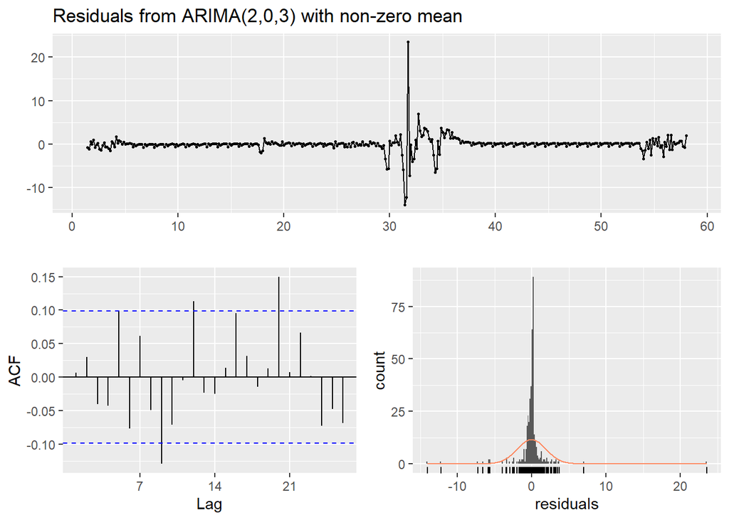

```
##
##  Ljung-Box test
##
## data:  Residuals from ARIMA(2,0,3) with non-zero mean
## Q* = 25.235, df = 8, p-value = 0.001418
##
## Model df: 6.   Total lags used: 14
```

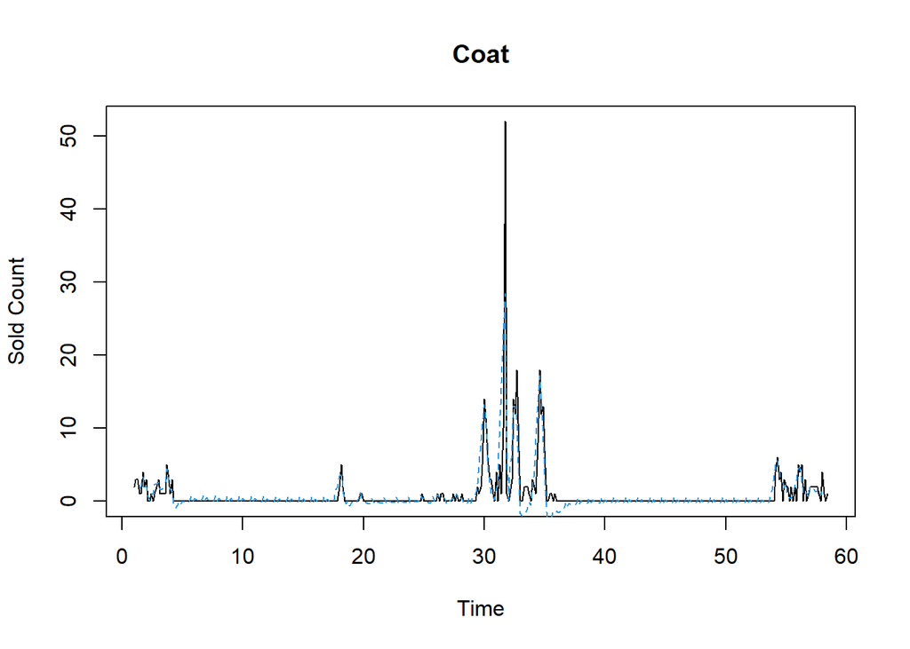

## ii) Bikini Top from TRENDYOLMILLA (Product ID: 73318567)

The plot of the sold count of the first bikini top is below.

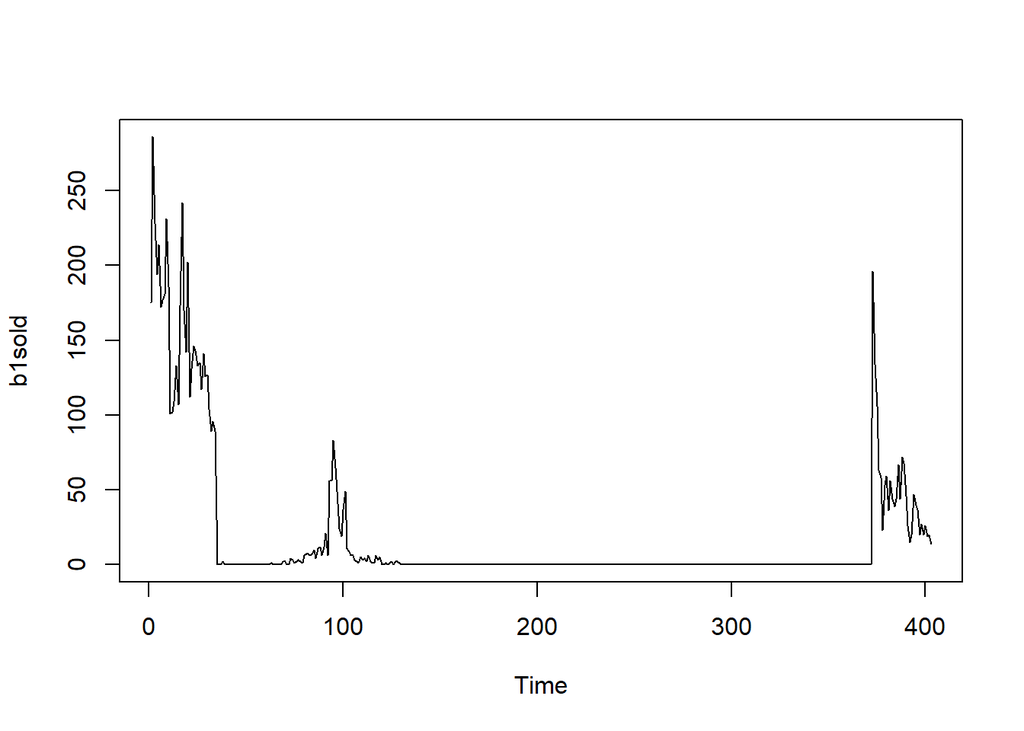

The plot of daily decomposition of the data is below. The type used is additive.

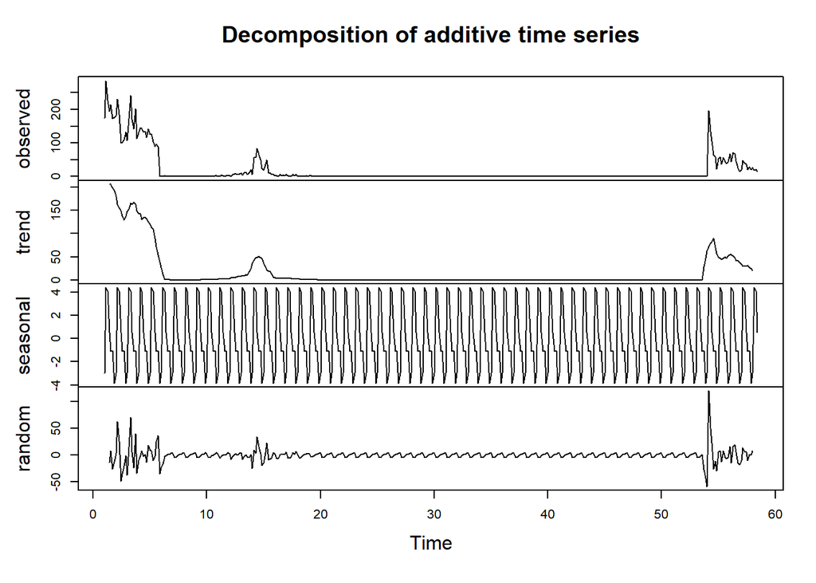

In the above plot, the trend of the data that was mentioned above is clearly seen. Like the decomposition of coat, the random component again includes the increases of the ends of the plot, more tamed though. Again, checking the stationarity of the random component,

```
##
##  KPSS Test for Level Stationarity
##
## data:  random_bik1
## KPSS Level = 0.023284, Truncation lag parameter = 5, p-value = 0.1
```

The KPSS test gives the result that the random component is stationary. Hence, a ARIMA model can be applied. Checking the ACF and PACF plots for this,

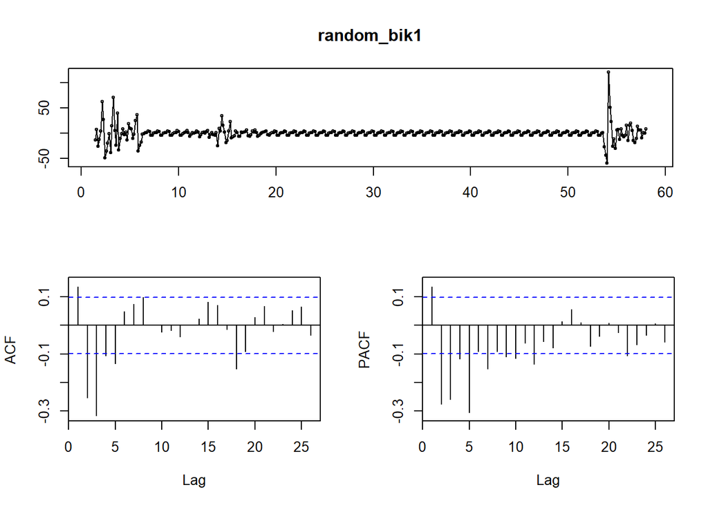

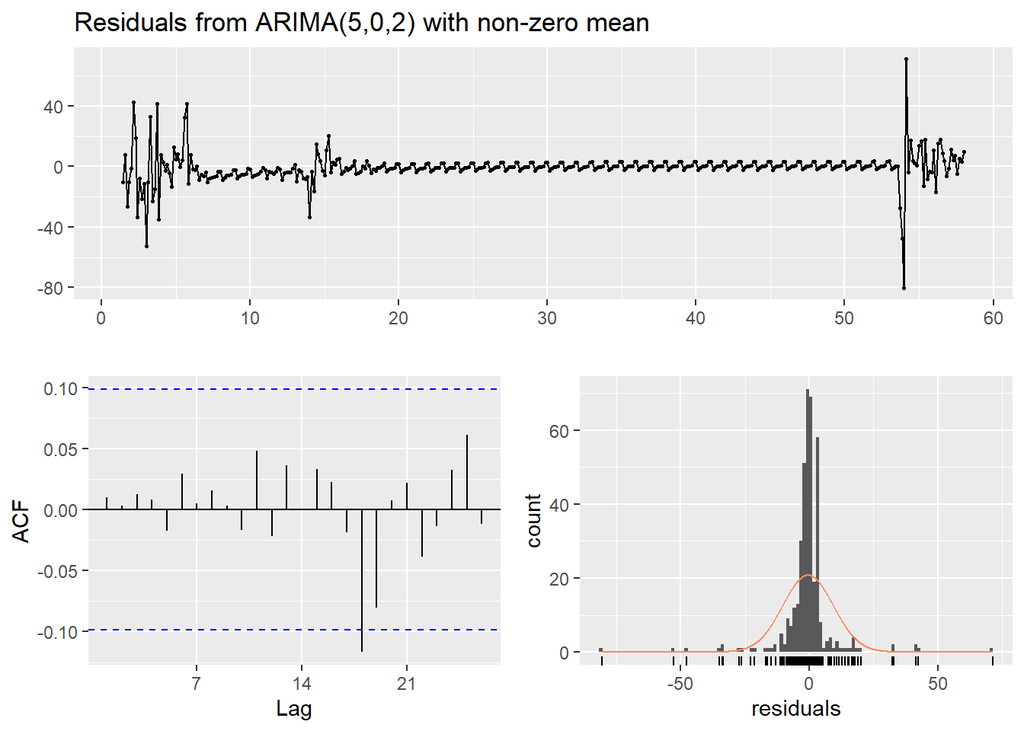

```
##
##  Ljung-Box test
##
## data:  Residuals from ARIMA(5,0,2) with non-zero mean
## Q* = 2.5172, df = 6, p-value = 0.8665
##
## Model df: 8.   Total lags used: 14
```

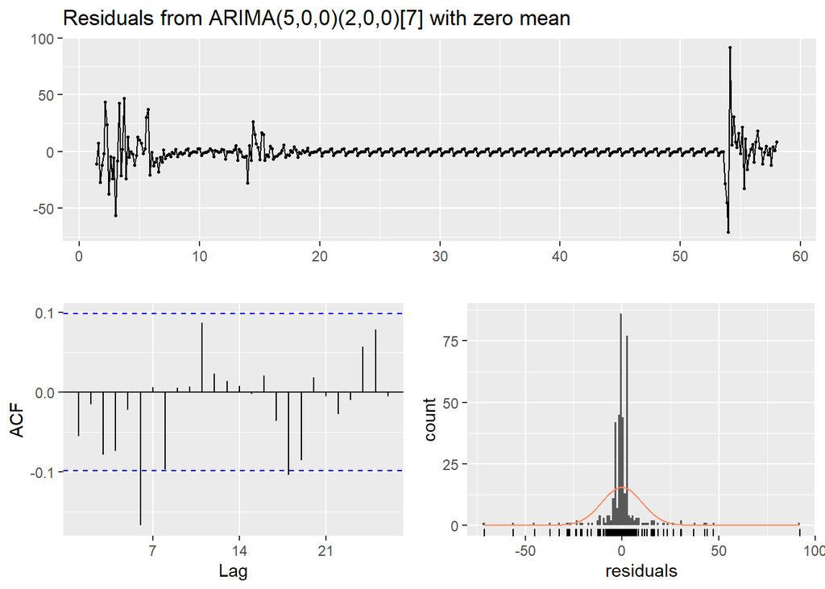

```
##
##  Ljung-Box test
##
## data:  Residuals from ARIMA(5,0,0)(2,0,0)[7] with zero mean
## Q* = 24.652, df = 7, p-value = 0.0008744
##
## Model df: 7.   Total lags used: 14
```

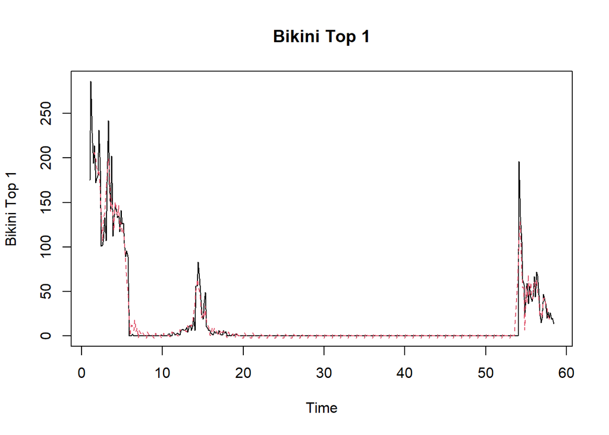

## iii) Bikini Top from TRENDYOLMILLA (Product ID: 32737302)

The plot of the second bikini top is below.

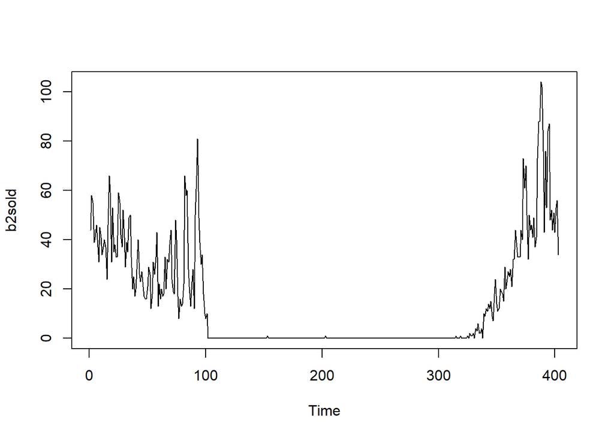

The plot of the decomposed data is

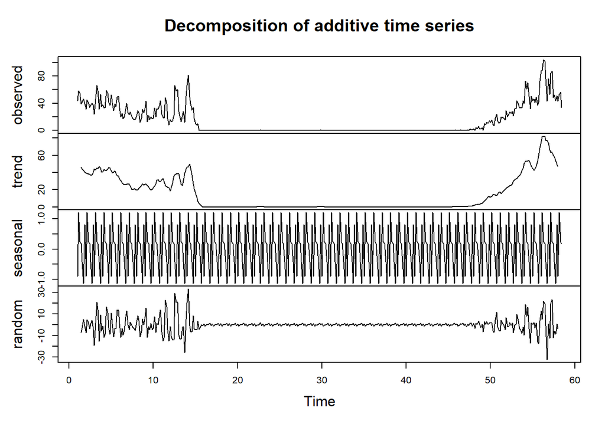

Above, the trend of the product mentioned above can be seen more clearly. After removing trend and seasonality components, the plot of the remaining part is seen as the random part of the decomposition. In order to check if an ARIMA model can be applied to the random component, the KPSS Test is run with the results

```
##
##  KPSS Test for Level Stationarity
##
## data:  random_bikini2
## KPSS Level = 0.0091779, Truncation lag parameter = 5, p-value = 0.1
```

which shows that the random component is stationary; hence, the ARIMA model can be applied.

In order to decide the lags of the ARIMA model, the obtained ACF and PACF plots are below.

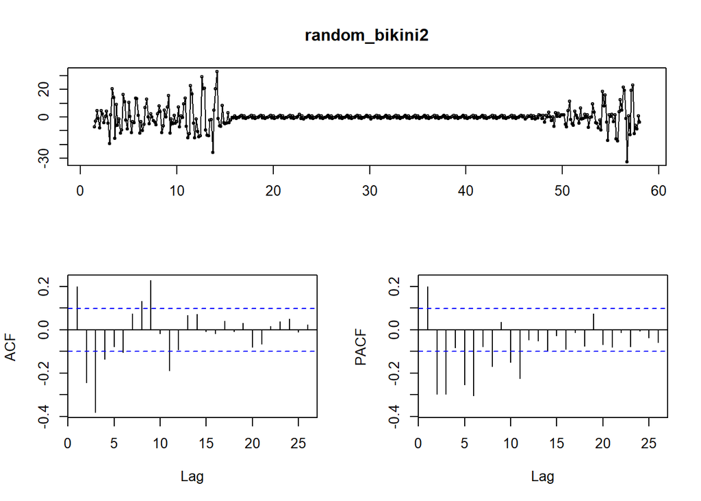

From the above plots and trying different ARIMA models in the submission period, we came to the conclusion that the appropriate ARIMA model is ARIMA(3,0,4), which has the smallest BIC value among others. In addition, the auto.arima function suggested using ARIMA(0,0,1)(0,0,2)[7]. When we compared these models in terms of how much the residuals fit our assumptions, the SARIMA model performed better than ARIMA in fitting the normal distribution, whereas ARIMA was better than SARIMA when it came to how many lags went beyond the confidence interval.

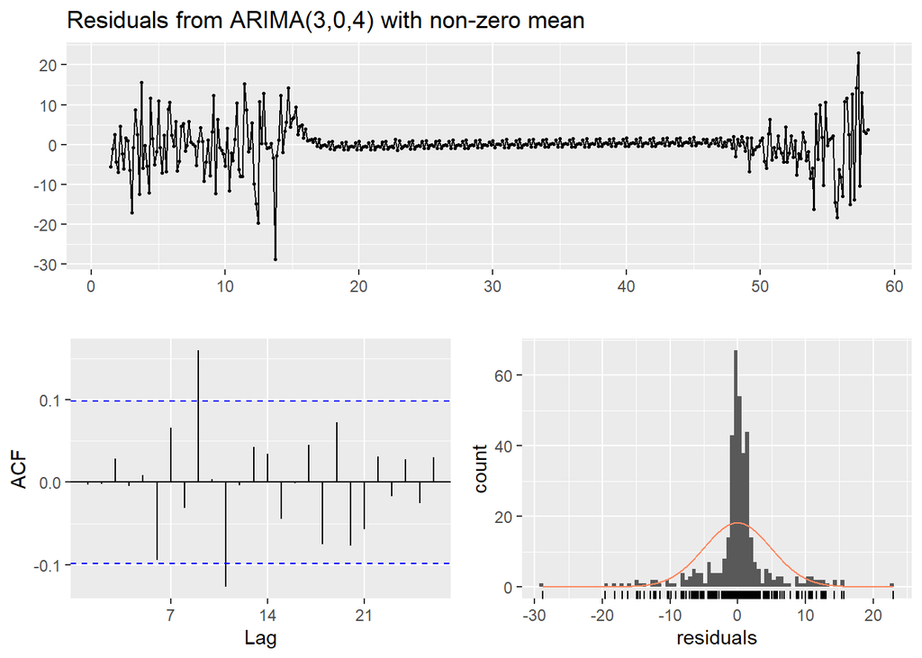

```
##
##  Ljung-Box test
##
## data:  Residuals from ARIMA(3,0,4) with non-zero mean
## Q* = 24.395, df = 6, p-value = 0.0004416
##
## Model df: 8.   Total lags used: 14
```

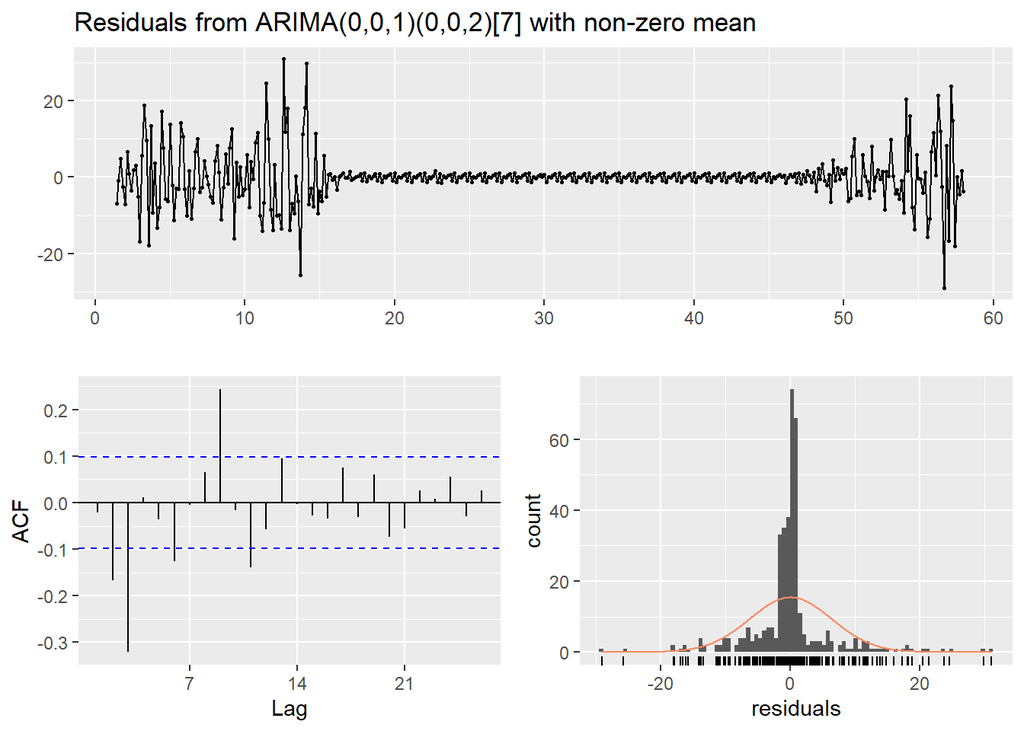

```
##
##  Ljung-Box test
##
## data:  Residuals from ARIMA(0,0,1)(0,0,2)[7] with non-zero mean
## Q* = 98.771, df = 10, p-value < 2.2e-16
##
## Model df: 4.   Total lags used: 14
```

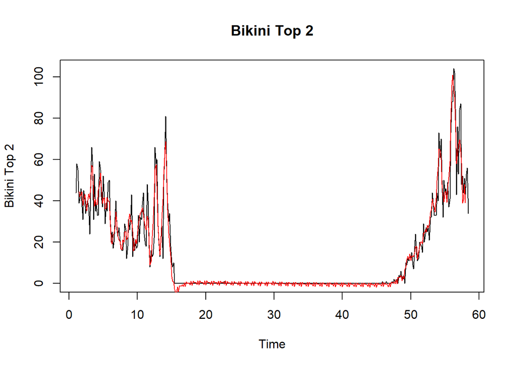

## iv. Tights from Trendyolmilla (Product ID=31515569)

The plot of the sold count is below:

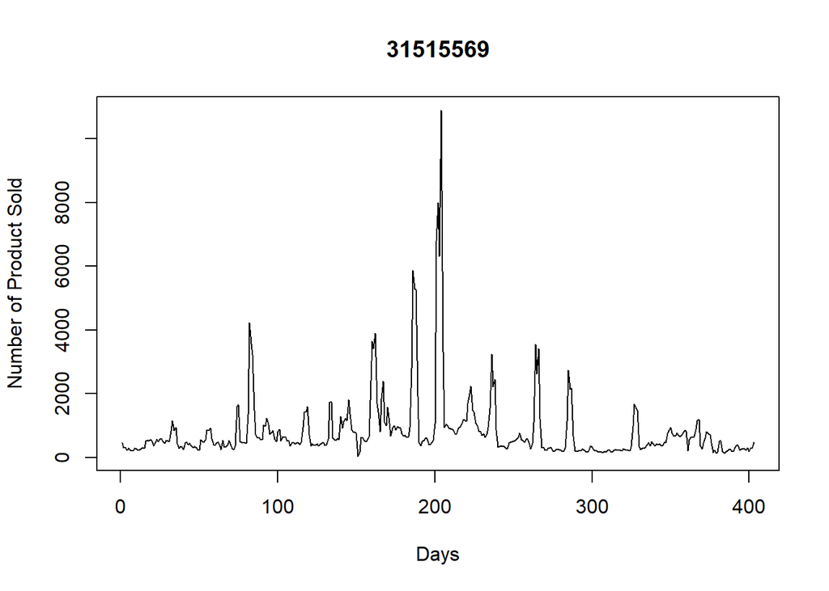

There are some peeks which may result from the discounts. For example, largest sale occured at the Black Friday.

Autocorrelation of the data can be seen below.

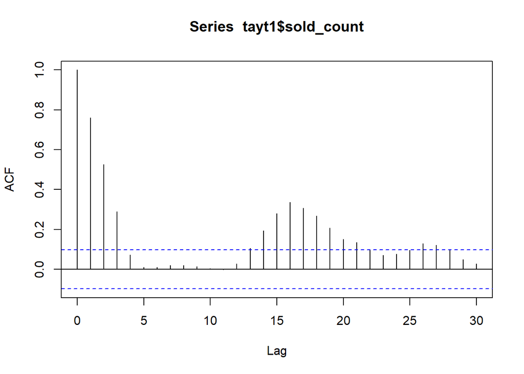

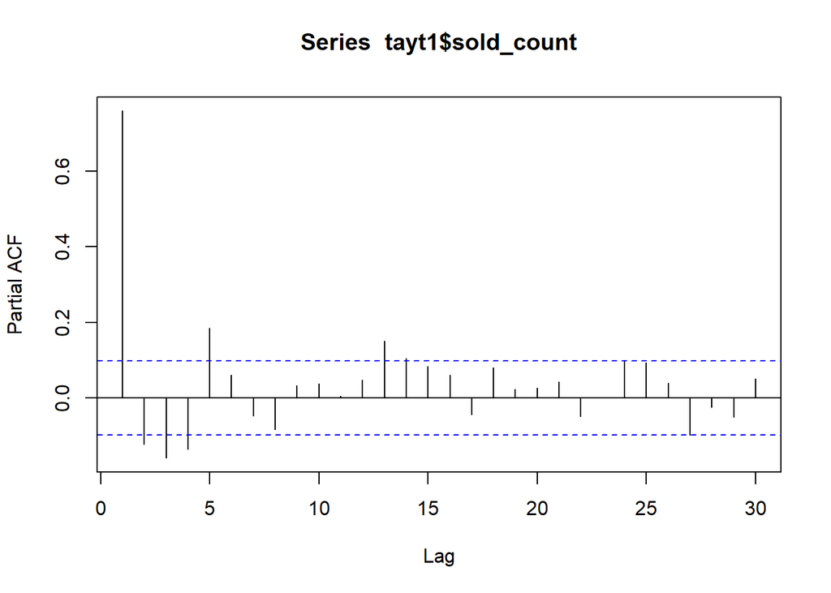

As we can see, the most important lag is 1. So, previous days sold count affect next day.

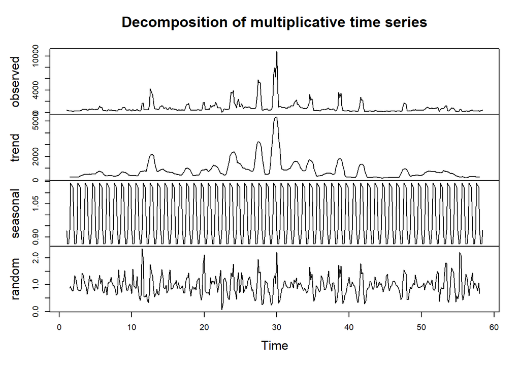

To eliminate the nonconstant variance, multiplicative decomposition is used with frequency of 7. To evaluate the random component we need to check the stationarity. KPSS unit-root test is used to understand the validity of our stationarity assumption.

```
##
## #######################
## # KPSS Unit Root Test #
## #######################
##
## Test is of type: mu with 5 lags.
##
## Value of test-statistic is: 0.0923
##
## Critical value for a significance level of:
##                 10pct  5pct 2.5pct  1pct
## critical values 0.347 0.463  0.574 0.739
```

Our test statistic is less than all the critical values. Hence, random component of the decomposition is stationary and we can build our ARIMA model for random term.To understand the order of the ARIMA model we should check the ACF and PACF plots.

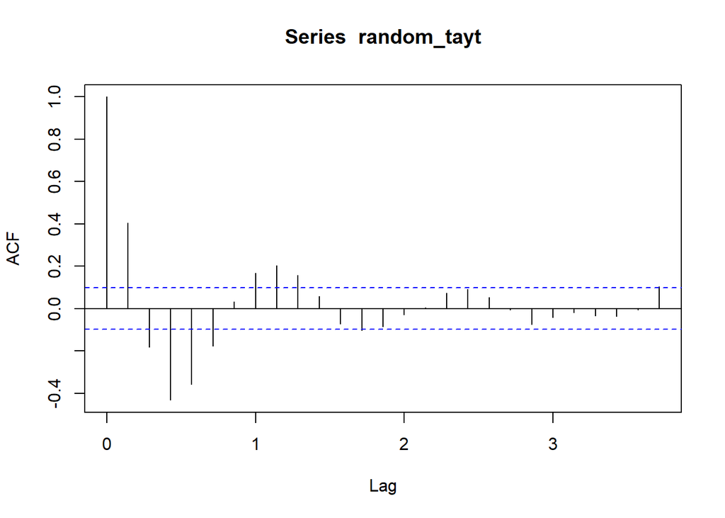

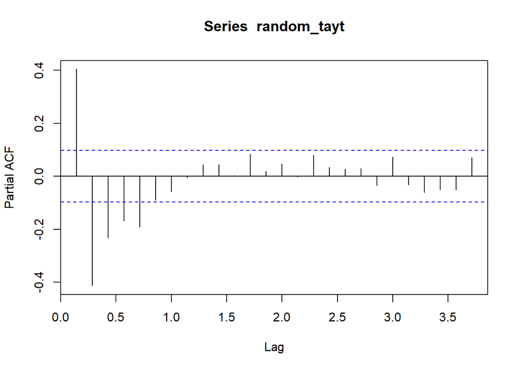

Negative sign at acf plot is a moving average behaviour and similarly negative values at pacf plot means there is a autoregressive component. So, several Arima models are tried and best AIC value is belong to (2,0,1) model. which is also the auto.arima suggestion.

```
## Series: random_tayt
## ARIMA(2,0,1) with non-zero mean
##
## Coefficients:
##          ar1      ar2      ma1    mean
##       1.0674  -0.6172  -0.6708  0.9659
## s.e.  0.0493   0.0392   0.0487  0.0083
##
## sigma^2 estimated as 0.07568:  log likelihood=-49.43
## AIC=108.86   AICc=109.02   BIC=128.78
```

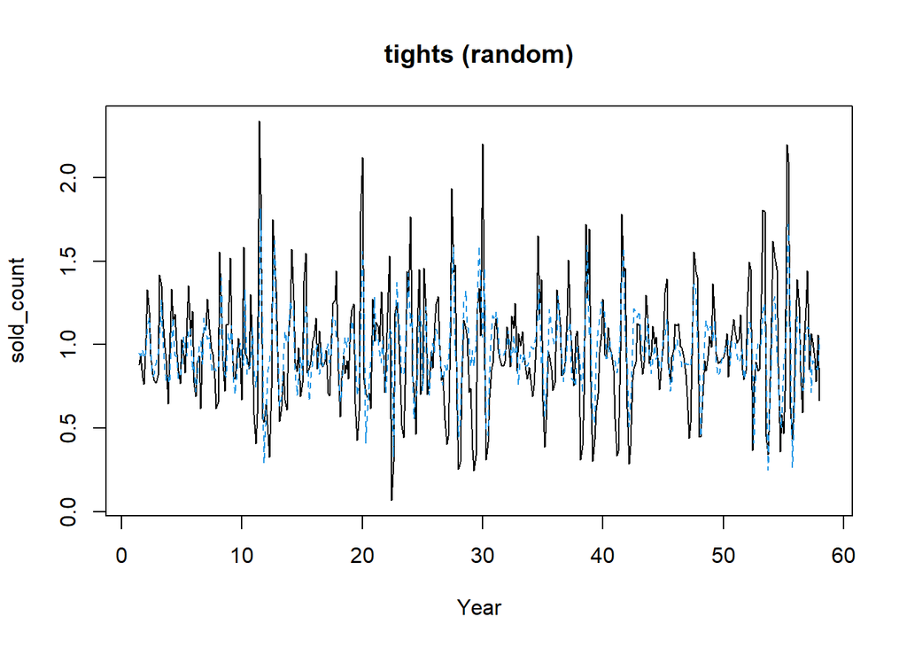

Actual random component and the fitted random values are plotted above. Actual sold data and the fitted values are plotted as below:

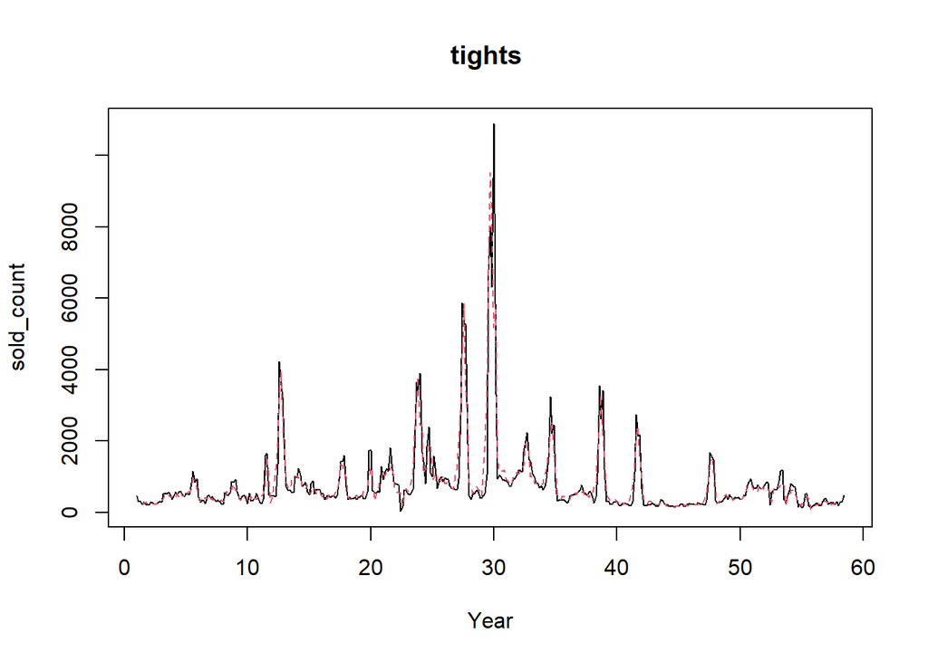

## v. Bluetooth Headphone from Xiaomi (Product ID: 6676673)

The plot of the sold count can be seen on the graph below.

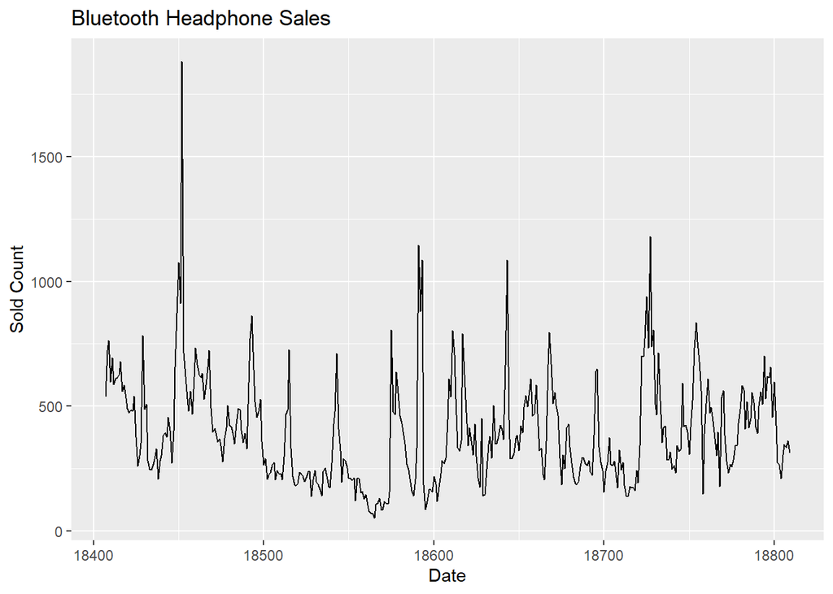

Fluctuation of this product is relatively high. In order to reduce the effect of these fluctuations and make the data stationary, multiplicative decomposition was implemented.

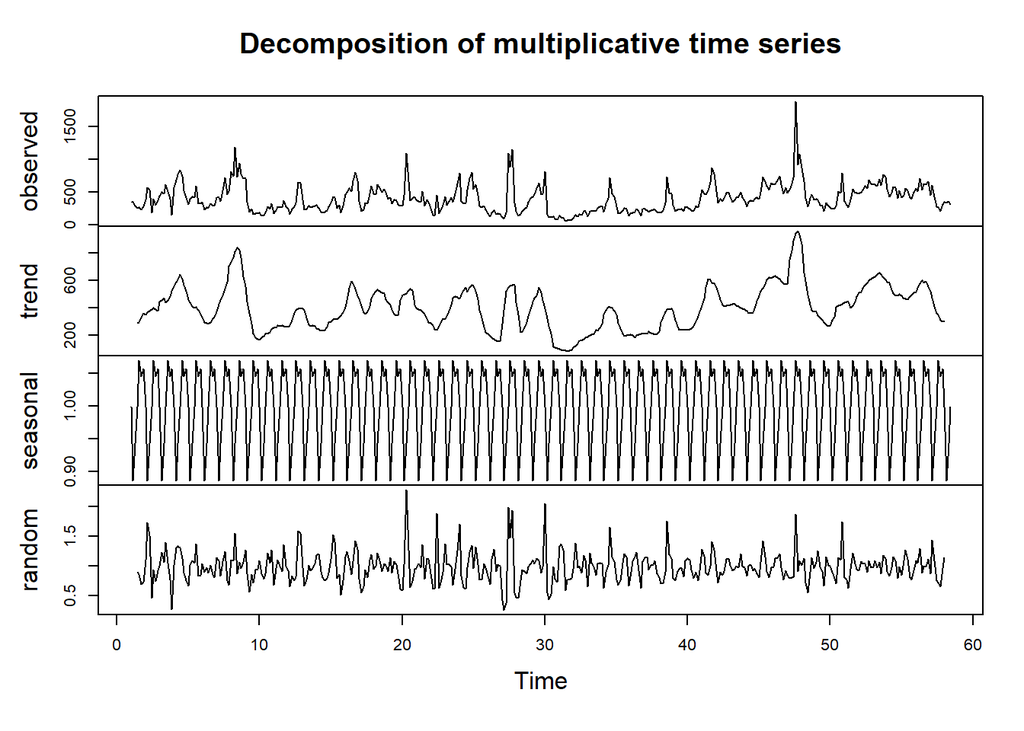

This is the graph of the decomposed data. From now on, random part of this data will be worked on, in other word the decomposed part of data. The KPSS unit-root test will help identifying the stationarity of this data.

```
##
## #######################
## # KPSS Unit Root Test #
## #######################
##
## Test is of type: mu with 5 lags.
##
## Value of test-statistic is: 0.4686
##
## Critical value for a significance level of:
##                 10pct  5pct 2.5pct  1pct
## critical values 0.347 0.463  0.574 0.739
```

Proceeding with this data, now the appropriate ARIMA model should be selected. The most accurate way to select this model may be analyzing the ACF and PACF graphs; however, auto.arima() function was implemented.

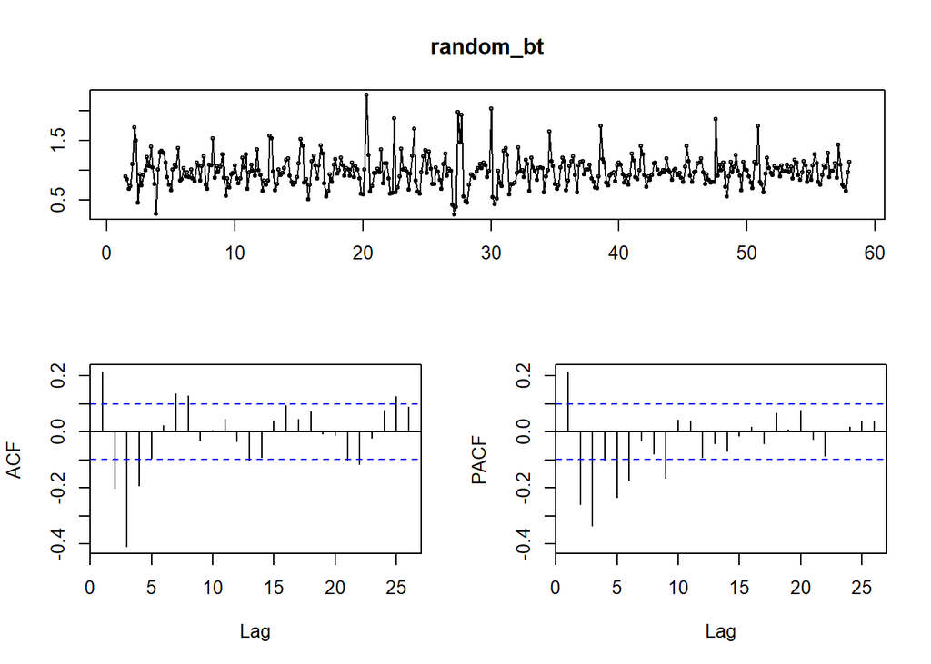

```
## Series: random_bt
## ARIMA(3,0,2)(1,0,0)[7] with non-zero mean
##
## Coefficients:
##          ar1     ar2      ar3      ma1      ma2    sar1    mean
##       0.1506  0.3185  -0.4439  -0.1007  -0.6194  0.0987  0.9862
## s.e.  0.1318  0.1283   0.0569   0.1378   0.1347  0.0594  0.0036
##
## sigma^2 estimated as 0.0491:  log likelihood=37.9
## AIC=-59.79   AICc=-59.42   BIC=-27.92
```

Having found the ARIMA model, fitted values were obtained by subtracting residuals from the random part. Since multiplicative transformation was implemented, transformed values were obtained by multiplying fitted values with trend and seasonal values.

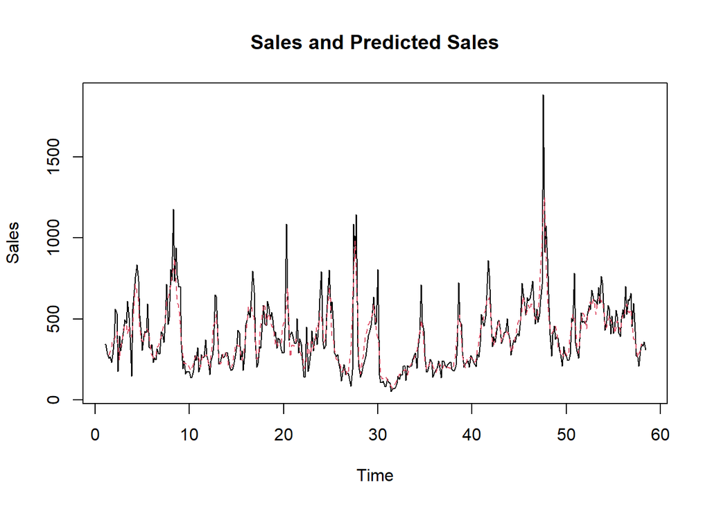

```
## integer(0)
```

## vi. Upright Vacuum Cleaner from Fakir (Product ID: 7061886)

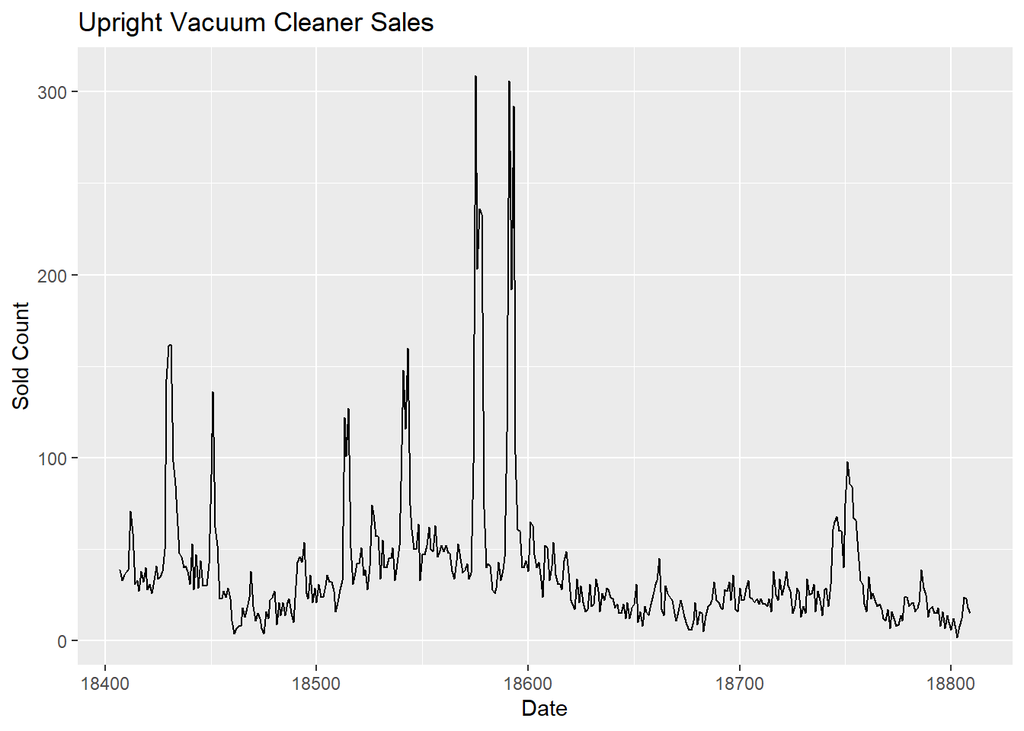

Just like bluetooth headphone, sales of upright vacuum cleaner have some relatively high fluctuations. In some cases, points that are away from mean + 2 * standard deviations can be interpreted as outlier points. Mean + 2 * standard deviation of this data is just below 115. As it can be seen, there are some points that are over 300. Just like the sales of bluetooth headphone, multiplicative decomposition seemed appropriate.

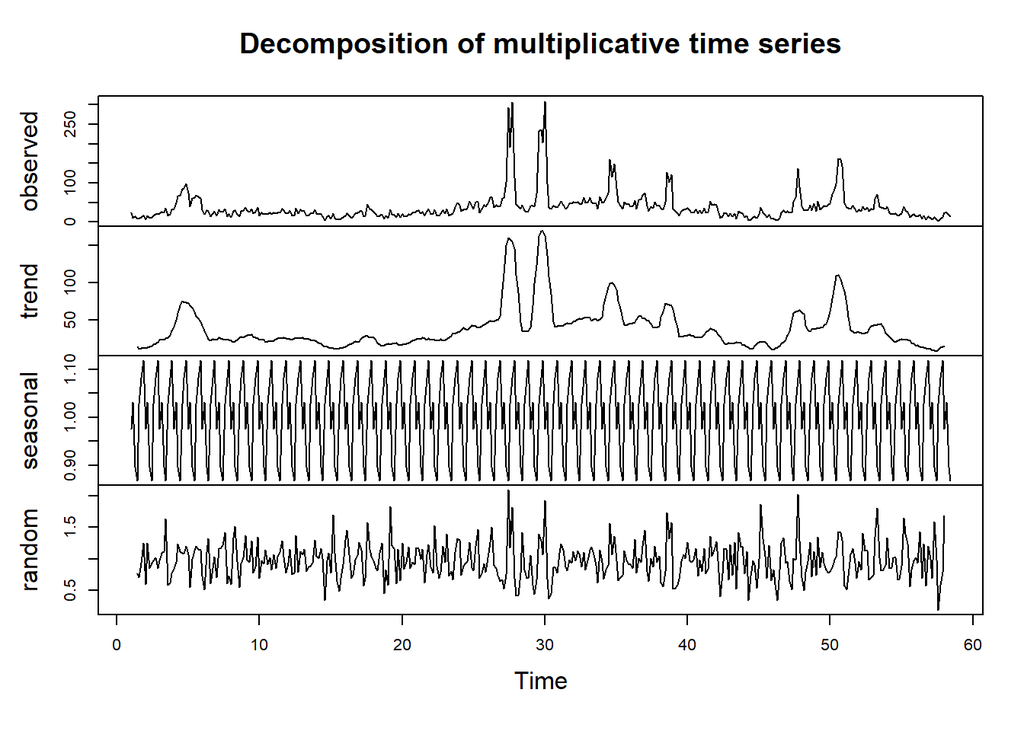

```r
random_vacuum <- vacuum_decomposed$random
test_vacuum = ur.kpss(random_vacuum)
summary(test_vacuum)
```

```
##
## #######################
## # KPSS Unit Root Test #
## #######################
##
## Test is of type: mu with 5 lags.
##
## Value of test-statistic is: 0.054
##
## Critical value for a significance level of:
##                 10pct  5pct 2.5pct  1pct
## critical values 0.347 0.463  0.574 0.739
```

Having confirmed the stationarity thanks to KPSS Unit Root test, ARIMA model can be selected. It would have been better if ARIMA model was found by analyzing ACF and PACF but it was faster doing it with auto.arima() and the results were good enough to use.

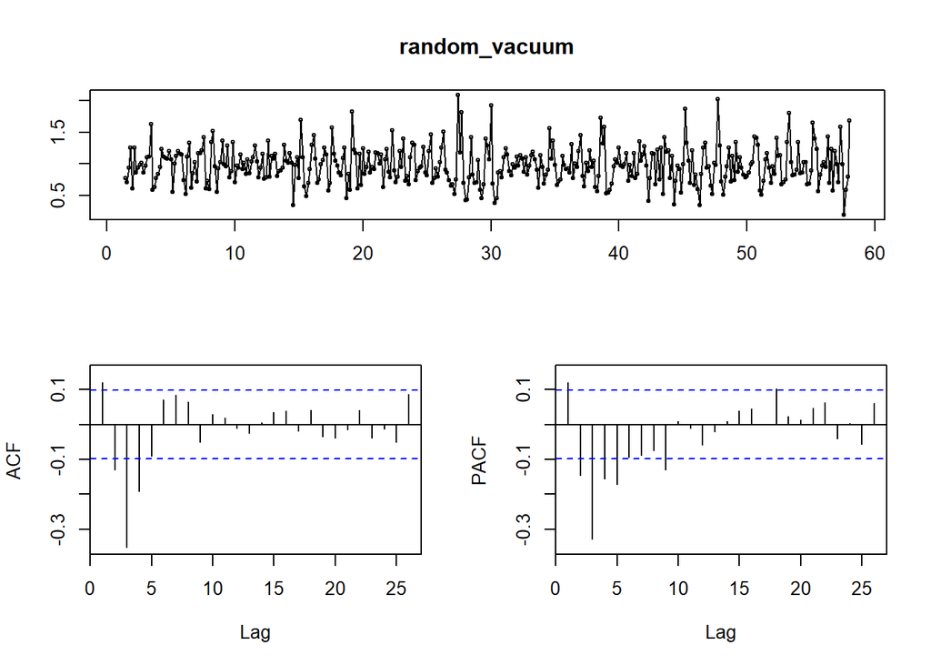

```
## Series: random_vacuum
## ARIMA(3,0,1) with non-zero mean
##
## Coefficients:
##          ar1      ar2      ar3      ma1    mean
##       0.7079  -0.1916  -0.2258  -0.7439  0.9803
## s.e.  0.0669   0.0607   0.0552   0.0525  0.0048
##
## sigma^2 estimated as 0.06956:  log likelihood=-32.12
## AIC=76.25   AICc=76.46   BIC=100.15
```

With the selected ARIMA model, it can be seen how well does the model fit the data.

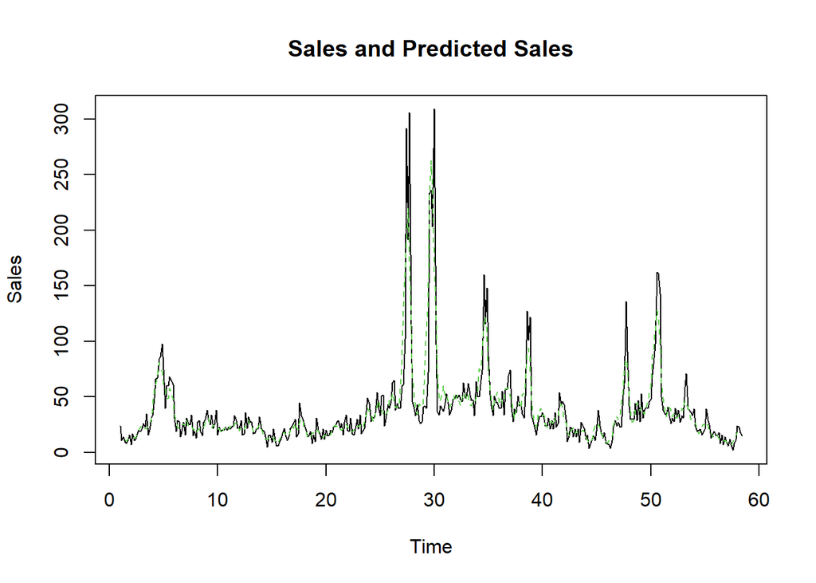

```
## integer(0)
```

## vii. Cleanser from La roche Posay (Product ID=85004)

The plot of the sold count is below:

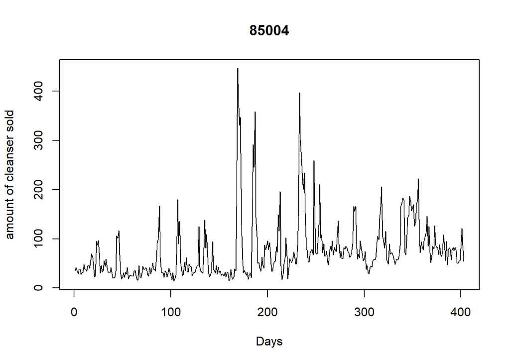

There are some peeks that come from the discounts.

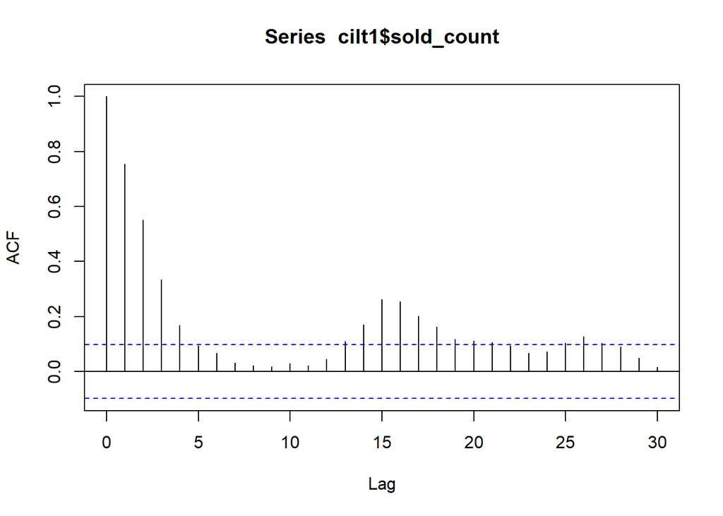

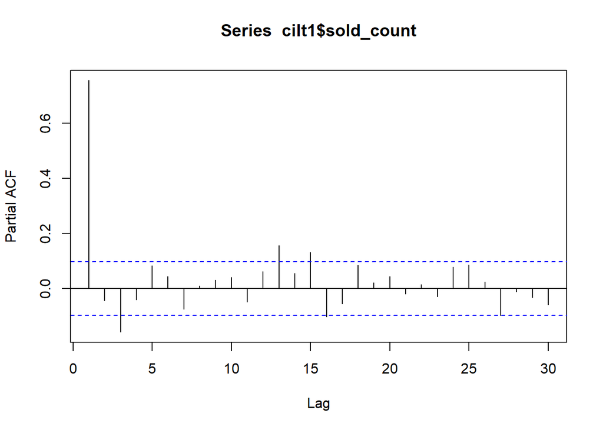

From the ACF plot we can see that there is a trend at our data. We need to decompose our data to find the stationary random term.

```
##
## #######################
## # KPSS Unit Root Test #
## #######################
##
## Test is of type: mu with 5 lags.
##
## Value of test-statistic is: 0.0061
##
## Critical value for a significance level of:
##                 10pct  5pct 2.5pct  1pct
## critical values 0.347 0.463  0.574 0.739
```

From the KPSS test we can say that there is no need to further examination, random component is stationary. We can deal with it by ARIMA models. to do that ACF and PACF is plotted below:

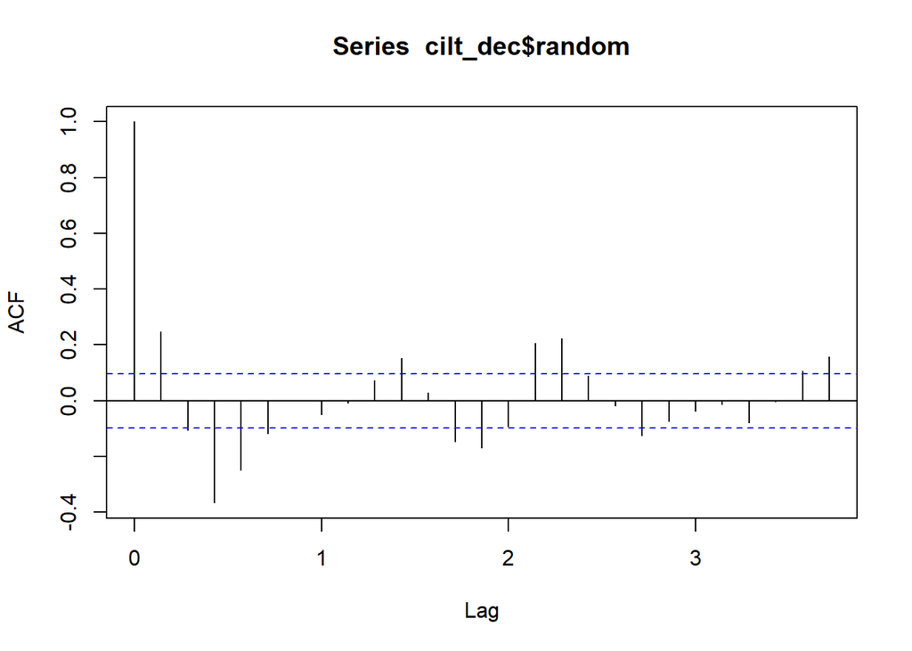

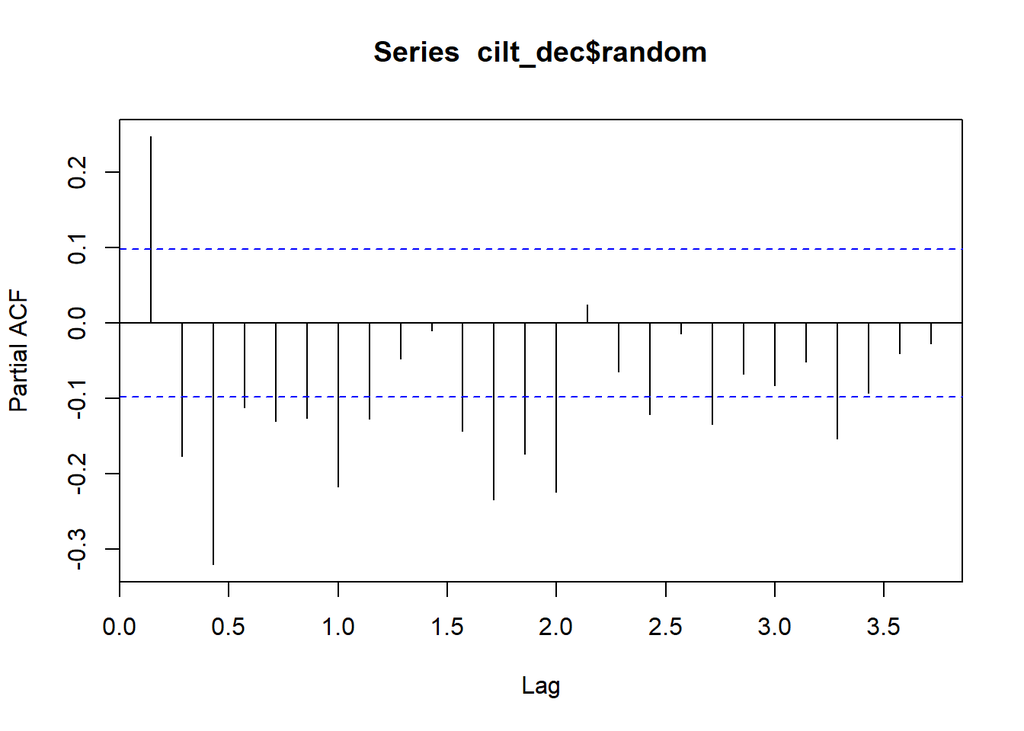

Negative PACF is clear sign of autoregressive model and there is some sort of seasonality at pacf.So model (3,0,1)(0,0,1) is better than tried models and the auto.arima.

```
##
## Call:
## arima(x = cilt_dec$random, order = c(3, 0, 1), seasonal = c(0, 0, 1))
##
## Coefficients:
##          ar1      ar2      ar3      ma1     sma1  intercept
##       0.8972  -0.2949  -0.2080  -1.0000  -0.2558     0.0029
## s.e.  0.0500   0.0649   0.0497   0.0065   0.0565     0.0137
##
## sigma^2 estimated as 620.4:  log likelihood = -1843.34,  aic = 3700.69
```

Now, we can move into fit the model and plot it.

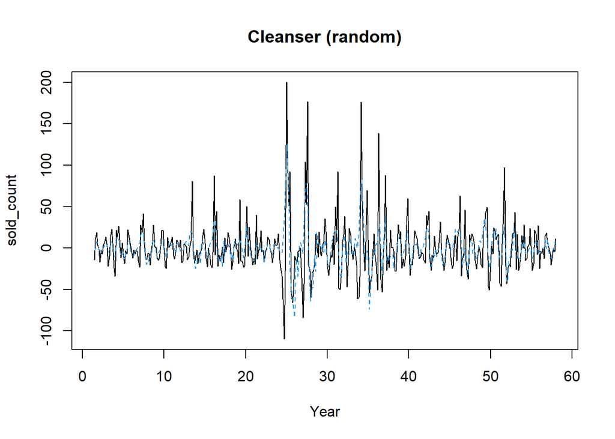

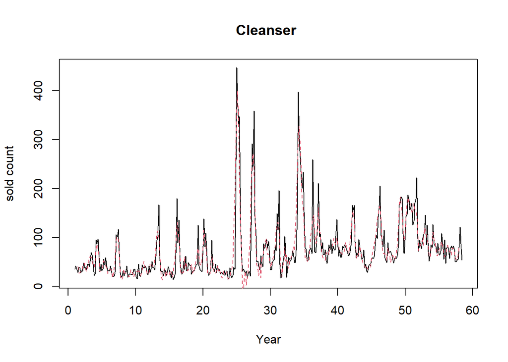

## viii. Wet Baby Wipes From Sleepy (Product ID=4066298)

The plot of the sold count is below:

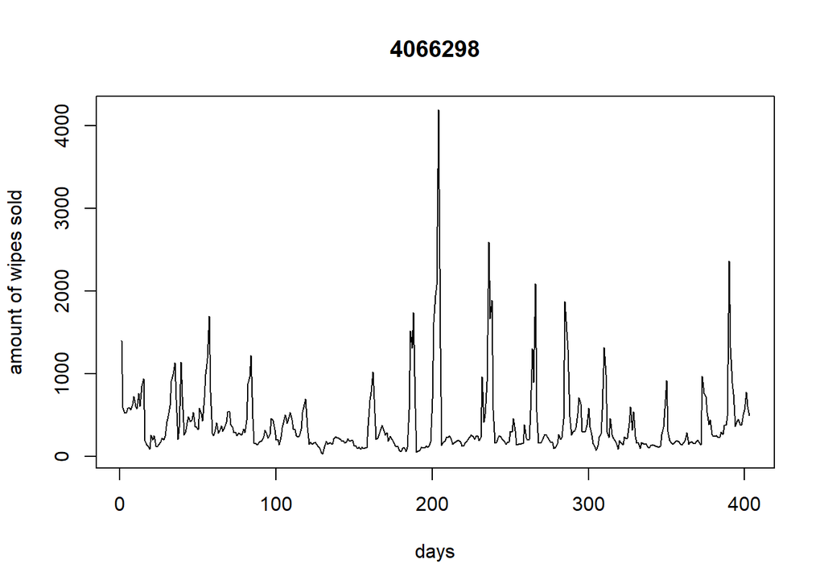

There are some peeks due to discount periods.

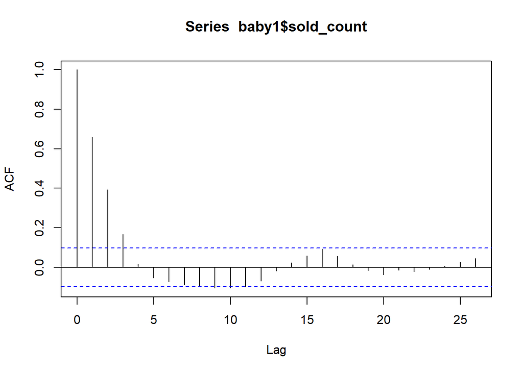

As we can se there is a autocorrelation between previous day and current day. To deal with the stationary term we need to do decomposition. Then, we should check the stationarity of the random term by applying the KPSS test.

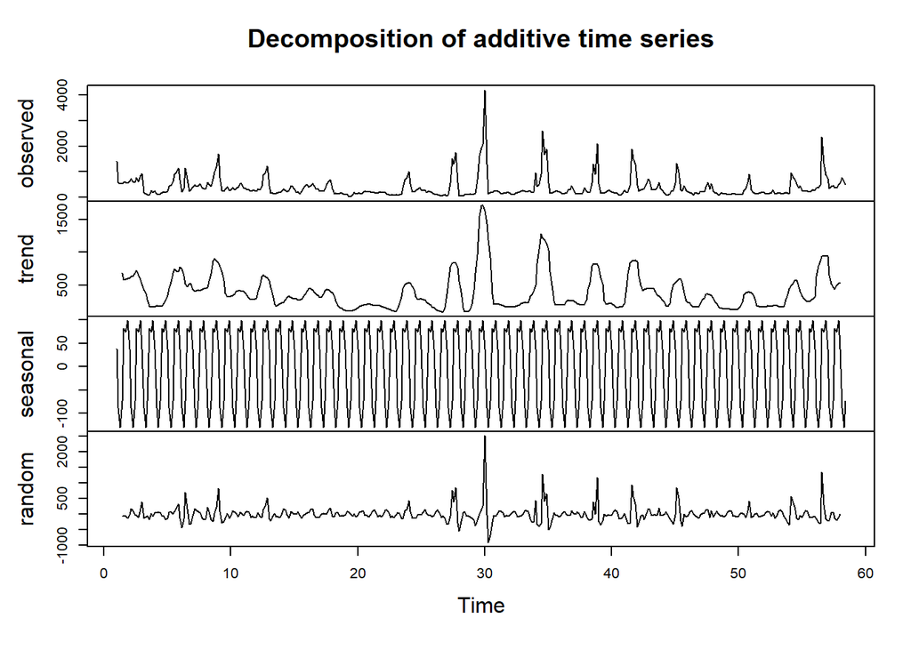

```
##
## #######################
## # KPSS Unit Root Test #
## #######################
##
## Test is of type: mu with 5 lags.
##
## Value of test-statistic is: 0.0072
##
## Critical value for a significance level of:
##                 10pct  5pct 2.5pct  1pct
## critical values 0.347 0.463  0.574 0.739
```

According to KPSS test random term is stationary.Now, we need to build our model with help of ACF and PACF plots below.

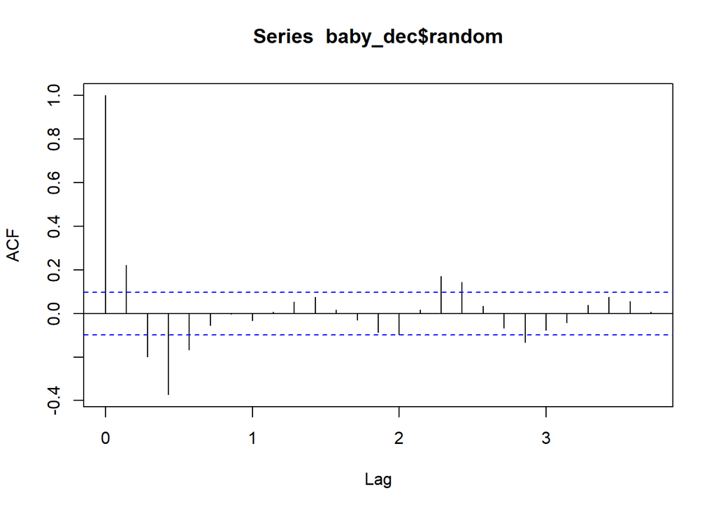

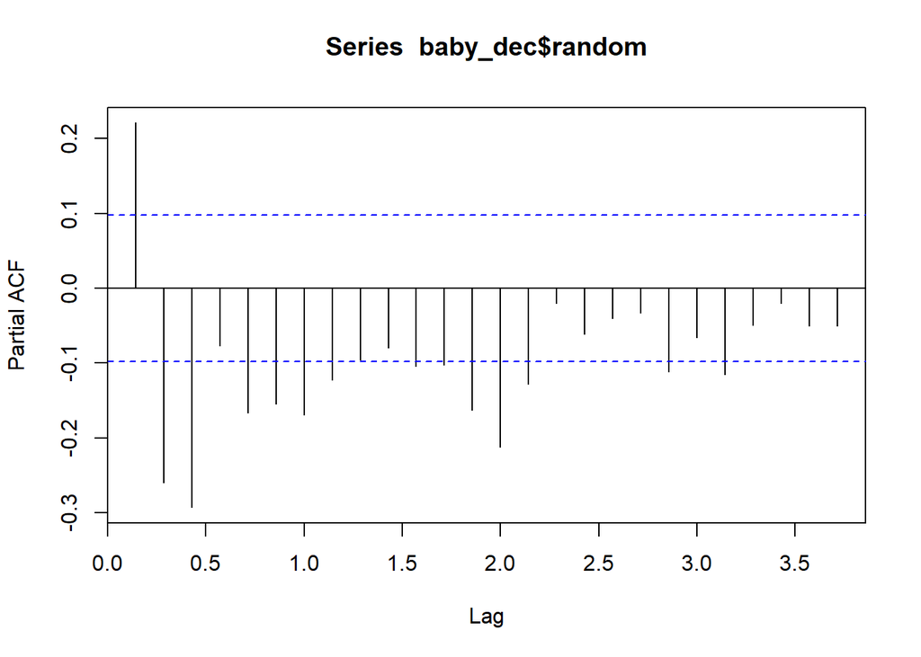

Negative PACF values lead to autoregressive behaviour. There is aspike at lag 3 on the ACF plot. Best model in terms of AIC values is (3,0,1)

```
##
## Call:
## arima(x = baby_dec$random, order = c(3, 0, 1))
##
## Coefficients:
##          ar1      ar2      ar3      ma1  intercept
##       0.9156  -0.3777  -0.1005  -1.0000    -0.0469
## s.e.  0.0499   0.0650   0.0499   0.0064     0.1608
##
## sigma^2 estimated as 42759:  log likelihood = -2682.95,  aic = 5377.91
```

Here is actual vs fitted plots for both random terms and the original series.

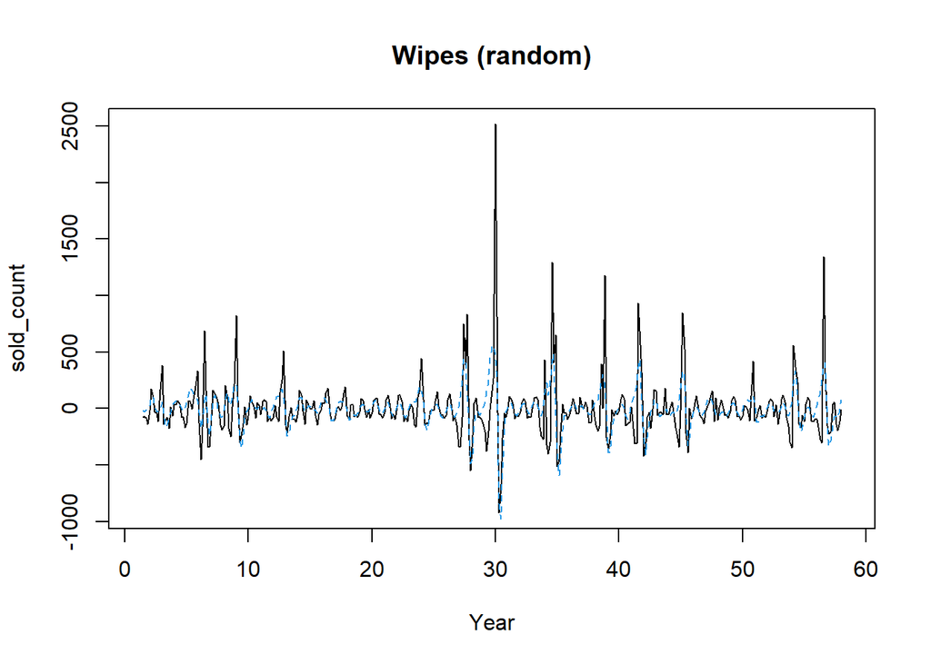

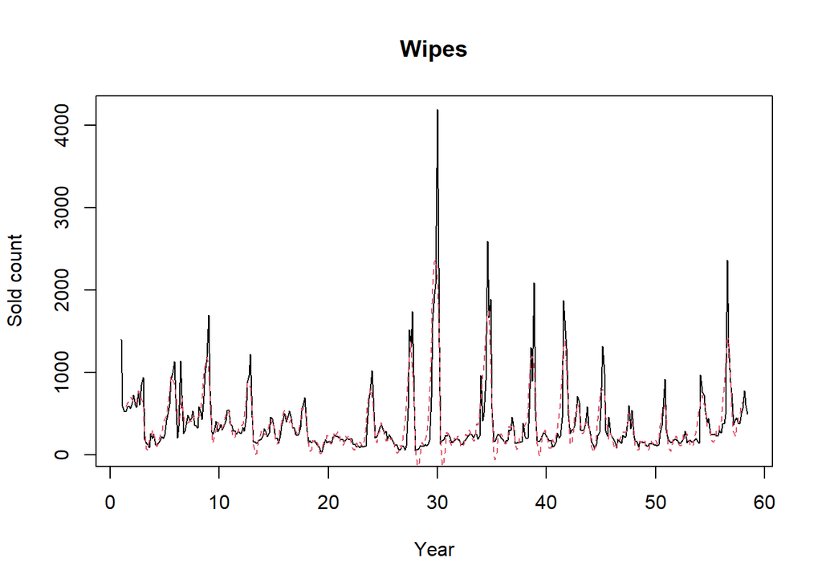

## ix. Electric Toothbrush from Oral-B (Product ID: 32939029)

Forecasting the sales of electric toothbrushes were quite similar as the other electronic products.

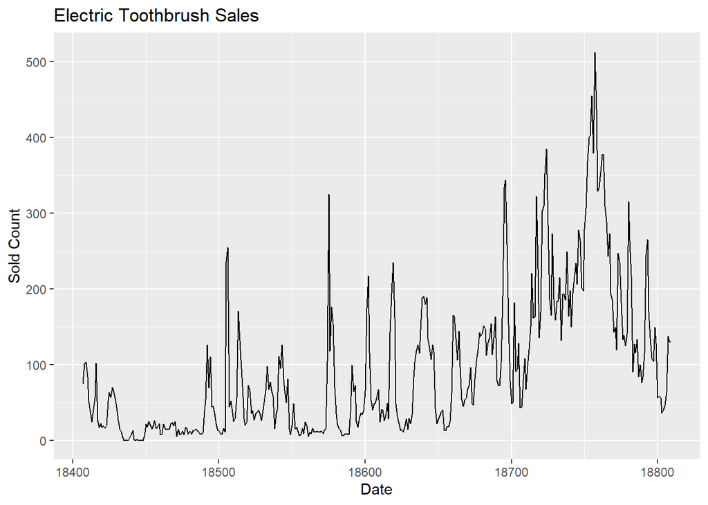

To reduce effect of up and down of this data, additive decomposition was implemented.

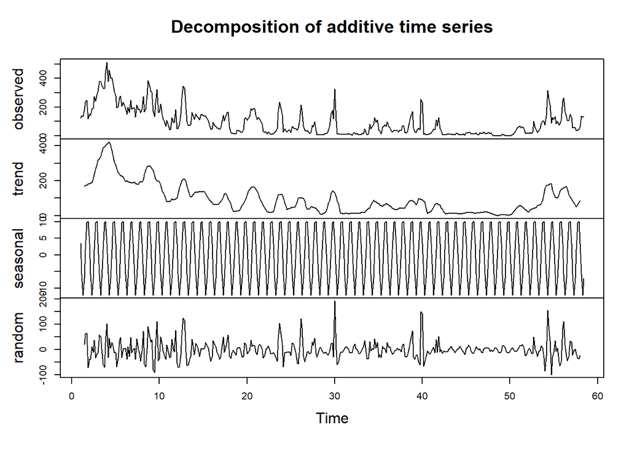

The model has some peaks around some special days; however, it is mostly okay and decomposed properly.

```
##
## #######################
## # KPSS Unit Root Test #
## #######################
##
## Test is of type: mu with 5 lags.
##
## Value of test-statistic is: 0.0242
##
## Critical value for a significance level of:
##                 10pct  5pct 2.5pct  1pct
## critical values 0.347 0.463  0.574 0.739
```

The result of KPSS Unit Root Test is an inditcator that decomposition was made correctly. With that, it is time to choose the ARIMA model. Just like the other products, auto.arima() was fast and thus preferred.

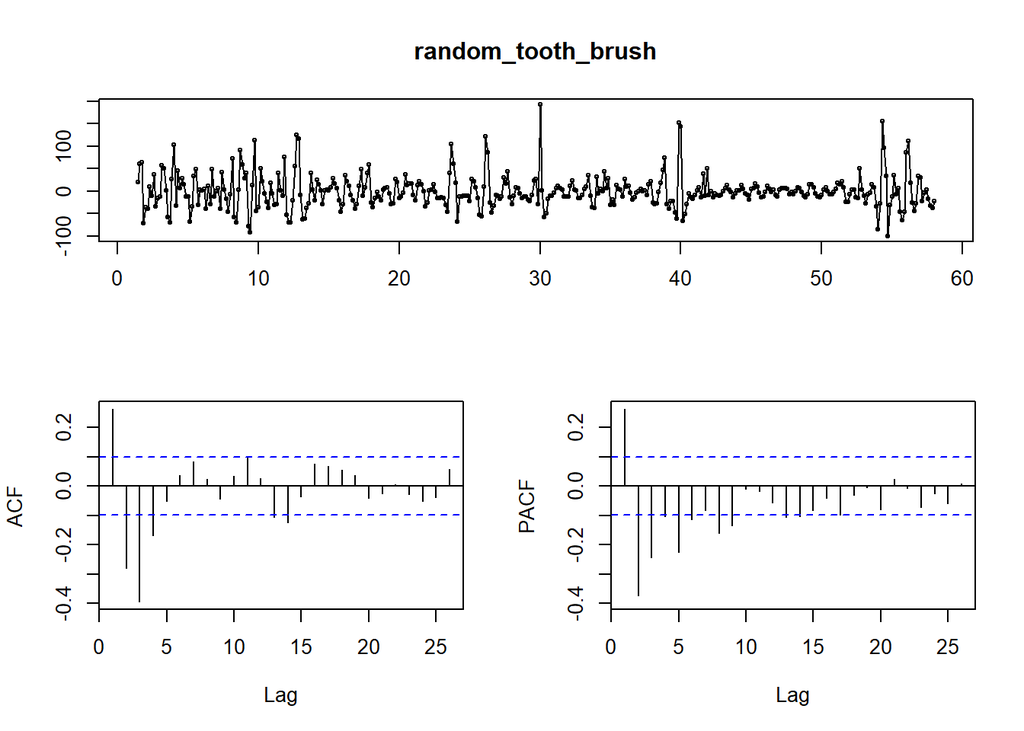

```
## Series: random_tooth_brush
## ARIMA(3,0,0)(1,0,0)[7] with zero mean
##
## Coefficients:
##          ar1      ar2      ar3    sar1
##       0.2631  -0.2845  -0.2495  0.0428
## s.e.  0.0486   0.0483   0.0489  0.0508
##
## sigma^2 estimated as 1026:  log likelihood=-1937.96
## AIC=3885.92   AICc=3886.08   BIC=3905.84
```

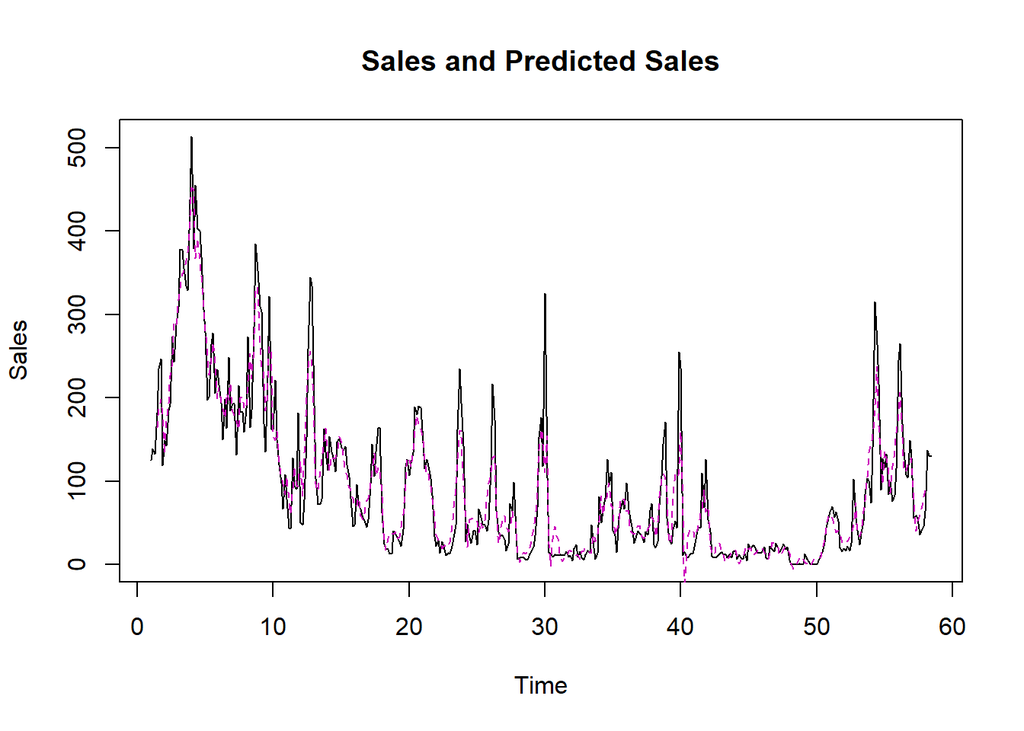

```
## integer(0)
```

# 3. Results

Predictions were made 4 days ahead and with the latest trend and seasonality values. To see results more clearly, a table that holds all necessary information was made. Since the data kept being updated after the last day of submission, the tables below are for the prediction of 03.07 since the predictions are made and these tables are for an instance; likewise, the provided codes will be for 03.07. However, the values used for the last day of the submissions will also be provided.

## Coat

Firstly, the table for the coat is below.

```
## Time Series:
## Start = c(57, 7)
## End = c(58, 5)
## Frequency = 7
##             random random_fitted actual  modelgen forecasted
## 57.85714 -1.221625    -0.3925592      0 0.8290663         NA
## 58.00000  2.745793     0.7297970      4 1.9840040         NA
## 58.14286        NA            NA      1        NA   1.314017
## 58.28571        NA            NA      0        NA   2.306820
## 58.42857        NA            NA      1        NA   1.302396
## 58.57143        NA            NA     NA        NA   1.408359
```

## Bikini Top 1

The table for the first bikini is below.

```
## Time Series:
## Start = c(57, 7)
## End = c(58, 5)
## Frequency = 7
##              random random_fitted actual modelgen forecasted
## 57.85714 -0.2916283    -1.4564388     20 18.83519         NA
## 58.00000  8.1394494    -0.3426438     26 17.51791         NA
## 58.14286         NA            NA     19       NA   21.77930
## 58.28571         NA            NA     20       NA   16.41154
## 58.42857         NA            NA     14       NA   18.02757
## 58.57143         NA            NA     NA       NA   16.65288
```

## Bikini Top 2

The table for the second bikini is below.

```
## Time Series:
## Start = c(57, 7)
## End = c(58, 5)
## Frequency = 7
##              random random_fitted actual modelgen forecasted
## 57.85714  0.6282159     -2.329576     51 48.04221         NA
## 58.00000 -3.6825610     -7.509633     43 39.17293         NA
## 58.14286         NA            NA     53       NA   49.13982
## 58.28571         NA            NA     56       NA   48.16038
## 58.42857         NA            NA     34       NA   49.52562
## 58.57143         NA            NA     NA       NA   47.19529
```

## Tights

Table that shows predictions and actual values is below:

```
## Time Series:
## Start = c(57, 7)
## End = c(58, 5)
## Frequency = 7
##            random randomfitted actual modelgen forecasted seasonality    trend
## 57.85714 1.056556    0.8507712    316 254.4530         NA   1.1249842 265.8571
## 58.00000 0.668097    1.0383234    184 285.9637         NA   0.9273034 297.0000
## 58.14286       NA           NA    302       NA   361.9368   0.8680287       NA
## 58.28571       NA           NA    298       NA   334.5431   0.8699174       NA
## 58.42857       NA           NA    483       NA   257.9350   0.9309061       NA
## 58.57143       NA           NA     NA       NA   307.4213          NA       NA
```

## Bluetooth Headphone

Table that holds predictions was made.

```
## Time Series:
## Start = c(58, 1)
## End = c(58, 5)
## Frequency = 7
##            random random_fitted actual modelgen forecasted
## 58.00000 1.139634      1.135697    348 346.7978         NA
## 58.14286       NA            NA    335       NA   260.5301
## 58.28571       NA            NA    361       NA   252.2830
## 58.42857       NA            NA    312       NA   271.9984
## 58.57143       NA            NA     NA       NA   267.8029
```

## Upright Vacuum Cleaner

Forecasted values could be found in the table called “last_table_vacuum”.

```
## Time Series:
## Start = c(58, 1)
## End = c(58, 5)
## Frequency = 7
##            random random_fitted actual modelgen forecasted
## 58.00000 1.688271      1.281332     24 18.21506         NA
## 58.14286       NA            NA     23       NA   11.86790
## 58.28571       NA            NA     18       NA   13.25765
## 58.42857       NA            NA     15       NA   15.42852
## 58.57143       NA            NA     NA       NA   14.58105
```

## Cleanser

Table can be seen below:

```
## Time Series:
## Start = c(57, 7)
## End = c(58, 5)
## Frequency = 7
##             random randomfitted actual modelgen forecasted seasonality    trend
## 57.85714 -4.287639     3.053431     56 63.34107         NA  -10.998076 71.28571
## 58.00000 11.276271    11.292192     80 80.01592         NA   -2.990557 71.71429
## 58.14286        NA           NA    121       NA   56.32355   11.511994       NA
## 58.28571        NA           NA     87       NA   55.98148   14.310464       NA
## 58.42857        NA           NA     54       NA   65.63595    7.931749       NA
## 58.57143        NA           NA     NA       NA   55.02584          NA       NA
```

## Wet Baby Wipes

Below the table that contains actual and predicted values can be seen below.

```
## Time Series:
## Start = c(57, 7)
## End = c(58, 5)
## Frequency = 7
##               random randomfitted actual modelgen forecasted seasonality
## 57.85714 -116.495493    -23.71904    508 600.7764         NA    98.78121
## 58.00000   -8.340104     72.85747    562 643.1976         NA    37.76868
## 58.14286          NA           NA    779       NA   610.7252   -88.30262
## 58.28571          NA           NA    612       NA   591.7976  -129.87660
## 58.42857          NA           NA    501       NA   524.7306   -74.15864
## 58.57143          NA           NA     NA       NA   579.2792          NA
##             trend
## 57.85714 525.7143
## 58.00000 532.5714
## 58.14286       NA
## 58.28571       NA
## 58.42857       NA
## 58.57143       NA
```

## Electric Toothbrush

Forecasts can be found in the table called last_table_tooth_brush.

```
## Time Series:
## Start = c(58, 1)
## End = c(58, 5)
## Frequency = 7
##             random random_fitted actual modelgen forecasted
## 58.00000 -22.92869      3.737125     64 90.66581         NA
## 58.14286        NA            NA    137       NA   77.76591
## 58.28571        NA            NA    131       NA   82.86872
## 58.42857        NA            NA    130       NA   89.55027
## 58.57143        NA            NA     NA       NA   89.50122
```

Obviously, our predictions were not always correct or sometimes close to the actual sales of the products. There occurred some increases and decreases that we could not explain, which can be due to the dirty nature of the data. That is, since some variables were only NA for some time, especially when the sold count is 0, which made it difficult to understand those increases and decreases harder.

Nonetheless, obviously there are many ways to improve our model and make sure it gives better results, such as adding regressors to our ARIMA models, although the regressors were not the best to work with, or doing more literature review that might help us understand the nature of quantities sold better; hence we would be able to come up with better models.

# 4. Conclusions and Future Work